# Sampling Systems

## Scope and Background Reading

This session is an introduction to sampling theory. It reviews the important ideas that pertain to sampling but leaves the detailed mathematics for your further study.

The material in this presentation and notes is based on Chapter 15 of [Benoit Boulet, Fundamentals of Signals and Systems](http://site.ebrary.com/lib/swansea/docDetail.action?docID=10228195) from the **Recommended Reading List** and you'll find the mathematical treatments there. There is much more detail in Chapter 9 of [Steven T. Karris, Signals and Systems: with Matlab Computation and Simulink Modelling, 5th Edition](http://site.ebrary.com/lib/swansea/docDetail.action?docID=10547416) from the **Required Reading List**.

## Agenda

- Sampling of Continuous-Time Signals
- Signal Reconstruction
- Discrete-time Processing of Continuous-Time Signals
- Sampling of Discrete-Time Systems

## Acknowledgements

We will be using an adaptation of a pair of demo scripts to illustrate *alialising*. These scripts were published by Prof. Charles A. Bouman, School of Electrical and Computer Engineering, Purdue University as part of the course materials for [ECE438: Digital Signal Processing](https://engineering.purdue.edu/VISE/ee438/demos/).

## Introduction

- The *sampling process* provides the bridge between continuous-time (CT) and discrete-time (DT) signals
- Sampling records discrete values of a CT signal at periodic instants of time.
- Sampled data can be used in *real-time* or *off-line* processing
- Sampling opens up possibility of processing CT signals through *finite impulse response* (FIR) and *infinite impulse response* (IIR) filters.

## A Real Example

I need a volunteer to provide a sound sample ....

1. I will use this [Live Script](https://uk.mathworks.com/help/matlab/matlab_prog/what-is-a-live-script-or-function.html) sampling_demo.mlx to sample your voice.
2. I will then playback the recording.
3. I will the plot the data.

```matlab
open sampling_demo
```

### Technical Details

- **Sampling rate**: 8000 samples per second (fs = 8 kHz)
- **Resolution**: 8 bits per sample
- **Channels**: 1 channel.
- **Reconstruction**: Matlab plays the audio back at 8192 samples per second.

### Question

What will the bit-rate be for playback?

## Sampling CT Signals

What is going on here?

### Time domain

Sampling can be modelled as the multiplication of a continuous-time signal by a sequence of periodic impulses as illustrated here.

[figure not shown]

This is a form of **modulation**

$T_s$ is the period of the periodic sampling function.

### Frequency domain

Multiplication in time domain is *convolution* in the frequency domain

[figure not shown]

$\omega_s$ is the frequency of the periodic sampling function = $2\pi/T_s$.

### The Mathematics

**The Sampled signal**:

$${x_s}(t) = \sum\limits_{k = - \infty }^{ + \infty } {x(k{T_s})\delta (t - k{T_s})} $$

**Frequency convolution**: $${X_s}(\omega ) = \frac{1}{{{T_s}}}\int_{ - \infty }^{ + \infty } {X(\upsilon )} \sum\limits_{k = - \infty }^{ + \infty } {\delta (t - \upsilon - k{\omega _s})} \,d\upsilon $$

**Sampling property**:

$${X_s}(\omega ) = \frac{1}{{{T_s}}}\int_{ - \infty }^{ + \infty } {\sum\limits_{k = - \infty }^{ + \infty } {X(\omega - k{\omega _s})} } \delta (t - \upsilon - k{\omega _s})\,d\upsilon $$

**Sifting property**:

$${X_s}(\omega ) = \frac{1}{{{T_s}}}\sum\limits_{n = - \infty }^{ + \infty } {X(\omega - k{\omega _s})}$$

### Nyquist-Shannon Sampling Theorem

Gives a sufficient condition to recover a continuous time signal from its samples $x(nT_s)$, $n$ is an integer.

**Sampling Theoreom**

Let $x(t)$ be a band-limited signal with $X(\omega) = 0$ for $|\omega|>\omega_M$.

Then $x(t)$ is uniquely determined by its samples $x(nT_s)$, $\infty <n < +\infty$ if

$$\omega_s > 2\omega_M,$$

where $\omega_s = 2\pi/T_s$ is the sampling frequency.

### Recovery of signal by filtering

[figure not shown]

### Ideal Lowpass Filter for CT Recovery from DT Sampled Signal

[figure not shown]

This is of course theoretical only!

### Sample-and-hold

[figure not shown]

### Sample-and-hold operator

[figure not shown]

## Matlab example

Basic set up

```matlab
clear all
w0 = 1;        % fundamental frequency rad/s
t0=2*pi/w0;    % period s
tmax = 1.5*t0; % plotable range
```

### Define a suitable signal

We will use a system with an underdamped second-order response.

The transfer function is: $$H(s) = \frac{\omega_0^2}{s^2 + 2\zeta\omega_0 s + \omega_0^2}$$

```matlab
syms s t
zeta = 0.3;
H = w0^2/(s^2 + 2*zeta*w0*s + w0^2)
```

```
H =

1/(s^2 + (3*s)/5 + 1)
```

#### Calculate and plot impulse response

```matlab
h = ilaplace(H)
```

```
h =

(10*91^(1/2)*exp(-(3*t)/10)*sin((91^(1/2)*t)/10))/91
```

```matlab
t = linspace(0,tmax,100);
xc = eval(h); % eval evaluates a symbolic expression as a Matlab command.
tc = t;
```

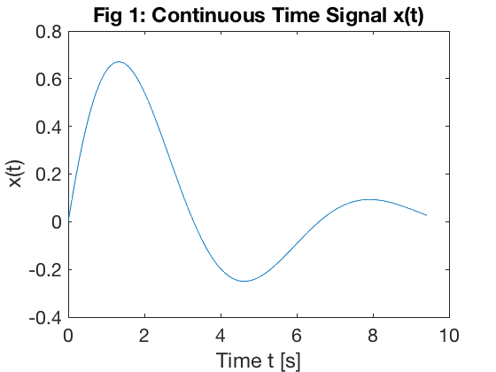

```matlab
plot(tc,xc)
title('Fig 1: Continuous Time Signal x(t)')
ylabel('x(t)')
xlabel('Time t [s]')
```

#### Calculate and plot sampled data

```matlab
ws = 4*w0; % twice minimum!
Ts = (2*pi)/ws;
t = 0:Ts:tmax;
xs = eval(h);
td = t;
```

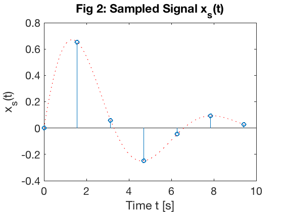

```matlab
stem(td,xs)
hold on
plot(tc,xc,'r:')
hold off
title('Fig 2: Sampled Signal x_s(t)')
ylabel('x_s(t)')
xlabel('Time t [s]')
```

## Signal Reconstruction

**Problem**

- We have a bandlimited signal that is sampled at the Nyquist-Shannon sampling frequency $\omega_s = 2\pi/T_s$.
- We therefore have a discrete-time (DT) signal $x(nT_s)$ from which we want to reconstruct the original signal.

### Perfect Signal Interpolation Using sinc Functions

Signal reconstructed with sinc function

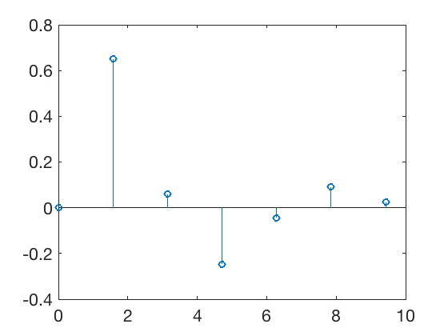

```matlab
stem(td,xs)
hold on
x = zeros(length(td),length(tc));
for k=1:length(td)
    xk = xs(k);
    sincx = xk*sin(pi*(tc - td(k))/Ts)./(pi*(tc - td(k))/Ts);
    x(k,:) = sincx;
end
```

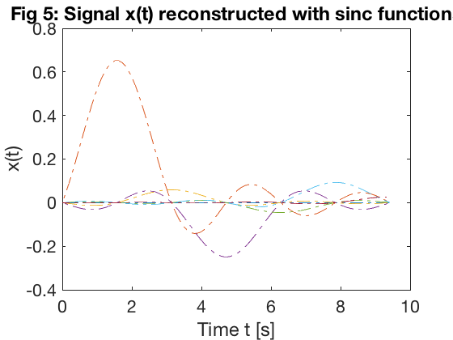

```matlab
plot(tc,x,'-.')
hold off
title('Fig 5: Signal x(t) reconstructed with sinc functions')
ylabel('x(t)')
xlabel('Time t [s]')
```

#### Reconstructed signal

Obtained by summing all the sinc functions

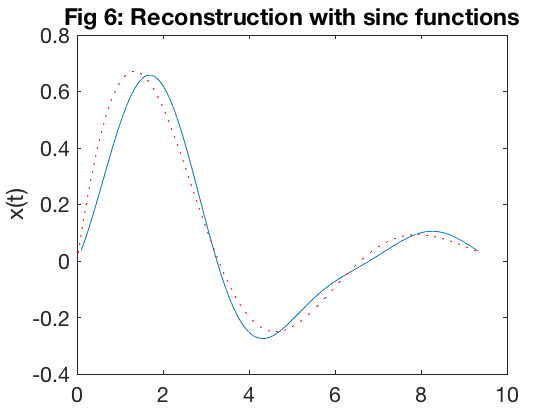

```matlab
plot(tc,sum(x),tc,xc,'r:')
title('Fig 6: Reconstruction with sinc functions')
ylabel('x(t)')
```

#### Signal reconstructed with zero-order hold (ZOH)

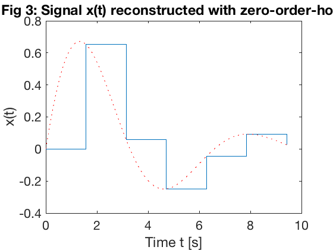

```matlab
stairs(td,xs)
hold on
plot(tc,xc,'r:')
title('Fig 3: Signal x(t) reconstructed with zero-order-hold')
ylabel('x(t)')
xlabel('Time t [s]')
```

#### Signal reconstructed with First-order hold (FOH)

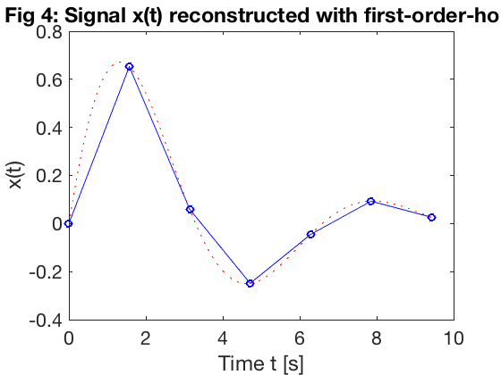

```matlab
plot(td,xs,'bo-',tc,xc,'r:')
title('Fig 4: Signal x(t) reconstructed with first-order-hold')
ylabel('x(t)')
xlabel('Time t [s]')
```

## Aliasing

- Aliasing Occurs when the sampling frequency is too low to ovoid overlapping between the spectra.
- When aliasing occours, we have violated the sampling theorem: that is $\omega_s < 2\omega_m$.
- When aliasing occurs, the original signal cannot be recovered by lowpass filtering.

### An Aliased Signal

[figure not shown]

### Example 1

We use the recording made at the start and run it through a script that effectively aliases the original signal be reducing the sampling frequency to less than half the original sampling frequency.

Here's the script: aliaseg1.mlx that I'll be using. (Also available as an m-file aliaseg1.m)

```matlab
open aliaseg1
```

### Example 2

Assume signal $x(t)=\cos(\omega_0 t)$ is sampled at a rate of $\omega_s = 1.5\omega_0$, violating the sampling theorem.

```matlab
open aliasing
```

We can see the effect on the plot below:

[figure not shown]

Image generated by aliasing.mlx (Also available as aliasing.m).

### Antialising Filters

- Most real signals are not band-limited so we have to artificially make them bandlimited using an *anti-aliasing filter*.
- An anti-aliasing filter is a low-pass filter whose cutoff frequency is lower than half the sampling frequency.
- This can produce some distortion at high-frequencies but this is often better than the distortion that would occur at low frequencies if aliasing was allowed to happen.
- For more on this topic see Pages 551—552 of Boulet.

### Example 3

This example uses anti-aliasing to downsample the audio. You should hear that the sound is less distorted as we sample below the sampling frequency of 8 kHz.

Script: aliaseg2.mlx (Also available as an m-file aliaseg2.m)

```matlab
open aliaseg2
```

### Practical application - digital audio

Human beings can hear sounds with frequencies up to around 20 kHz so when recording music in the modern sound studio (or phone or PC for that matter) the audio signal is antialiased with a 22 kHz filter. The signal is then sampled at 44.1 kHz before being stored for later processing and/or playback.

## DT Processing of CT Signals

[figure not shown]

## Sampling of DT Signals

- In modern signal processing and digital communications many of the operations that were once done in continuous time are now done entirely in discrete time.
- For example, we can implement sampling and modulation in discrete time.
- We can also upsample (interpolate between samples) or downsample (reduce the number of samples in a discrete-time signal)

These topics are left to you for further study.

## Summary

- Sampling of Continuous-Time Signals
- Signal Reconstruction
- Discrete-time Processing of Continuous-Time Signals
- Sampling of Discrete-Time Systems

*Next session*

- The Z-Transform

### Answer to Question

bit rate = [number of samples per second] x [number of bits per sample] x [number of channels]

bit rate = $8192 \times 8 \times 1$ bits/second [baud]

bit rate = $65,536$ bits/second